# Analyse des Correspondances Multiples

Jeu de données data

### 1. Observation d’individus extrêmes

L’analyse des graphes ne révèle aucun individu singulier.

### 2. Distribution de l’inertie

L’inertie des axes factoriels indique d’une part si les variables sont structurées et suggère d’autre part le nombre judicieux de composantes principales à étudier.

Les 2 premiers axes de l’ analyse expriment **8.98%** de l’inertie totale du jeu de données ; cela signifie que 8.98% de la variabilité totale du nuage des individus (ou des variables) est représentée dans ce plan. C’est un pourcentage très faible, et le premier plan ne représente donc seulement qu’une part de la variabilité contenue dans l’ensemble du jeu de données actif. Cette valeur est supérieure à la valeur référence de **4.52%**, la variabilité expliquée par ce plan est donc significative (cette intertie de référence est le quantile 0.95-quantile de la distribution des pourcentages d’inertie obtenue en simulant 1566 jeux de données aléatoires de dimensions comparables sur la base d’une distribution uniforme).

Du fait de ces observations, il serait alors certainement nécessaire de considérer également les dimensions supérieures ou égales à la troisième dans l’analyse.

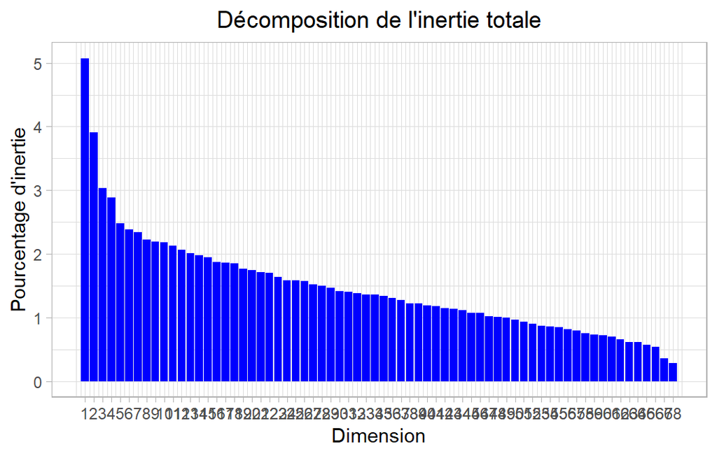

**Figure 2 - Décomposition de l’inertie totale**

Une estimation du nombre pertinent d’axes à interpréter suggère de restreindre l’analyse à la description des 22 premiers axes. Ces composantes révèlent un taux d’inertie supérieur à celle du quantile 0.95-quantile de distributions aléatoires (51.35% contre 42.25%). Cette observation suggère que seuls ces axes sont porteurs d’une véritable information. En conséquence, la description de l’analyse sera restreinte à ces seuls axes.

### 3. Description du plan 1:2

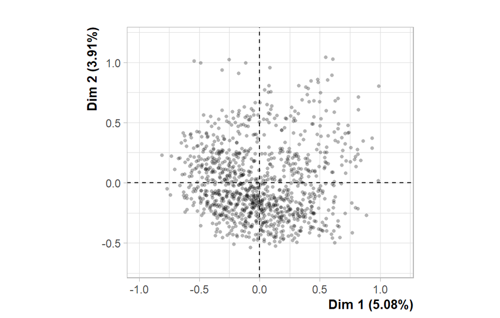

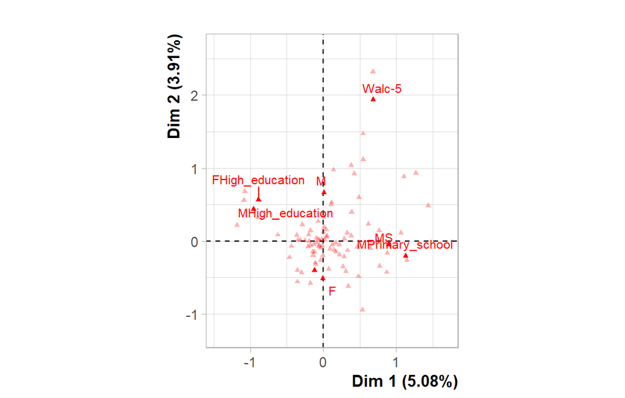

**Figure 3.2 - Graphe des variables (ACM)** *Les variables libellées sont celles les mieux représentées sur le plan.*

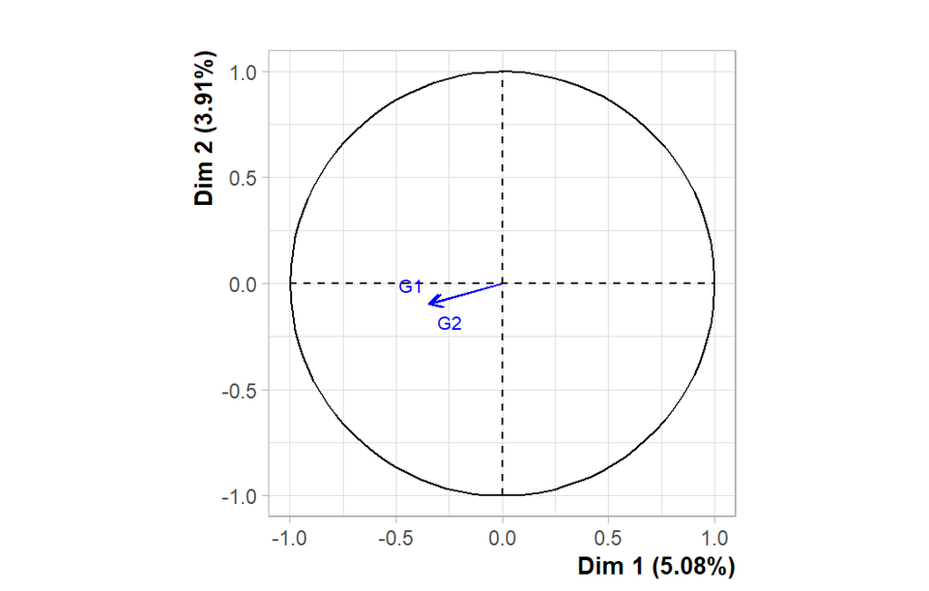

**Figure 3.3 - Graphe des variables quantitatives (ACM)** *Les variables libellées sont celles les mieux représentées sur le plan.*

La **dimension 1** oppose des individus caractérisés par une coordonnée fortement positive sur l’axe (à droite du graphe) à des individus caractérisés par une coordonnée fortement négative sur l’axe (à gauche du graphe).

Le groupe 1 (caractérisés par une coordonnée positive sur l’axe) partage :

- une forte fréquence des modalités telles que *internet=int-YES*, *sex=F*, *Mjob=Mjob_at_home*, *school=MS*, *Medu=MPrimary_school*, *Dalc=Dalc-1*, *Fedu=FPrimary_school*, *course=portuguese*, *traveltime=t15-30* et *address=R* (du plus commun au plus rare).
- une faible fréquence des modalités telles que *Medu=MHigh_education*, *internet=int-NO*, *sex=M*, *Fedu=FHigh_education*, *school=GP*, *traveltime=t0-15*, *Mjob=Mjob_teacher*, *course=Math*, *address=U* et *goout=go_out-5* (du plus rare au plus commun).

Le groupe 2 (caractérisés par une coordonnée positive sur l’axe) partage :

- une forte fréquence des modalités telles que *studytime=s0-2*, *higher=highEdu-YES*, *Medu=MPrimary_school*, *school=MS*, *address=R*, *Fedu=FPrimary_school*, *goout=go_out-5*, *Walc=Walc-5*, *famsup=famsup-YES* et *sex=M* (du plus commun au plus rare).
- une faible fréquence des modalités telles que *Medu=MHigh_education*, *Dalc=Dalc-1*, *Walc=Walc-1*, *failures=0*, *higher=highEdu-NO*, *traveltime=t0-15*, *school=GP*, *address=U*, *famsup=famsup-NO* et *Fedu=FHigh_education* (du plus rare au plus commun).

Le groupe 3 (caractérisés par une coordonnées négative sur l’axe) partage :

- une forte fréquence des modalités telles que *Dalc=Dalc-1*, *school=GP*, *sex=F*, *Walc=Walc-1*, *famsup=famsup-NO*, *address=U*, *Fedu=FSecondary_school*, *failures=0*, *traveltime=t0-15* et *reason=reason_reputation* (du plus commun au plus rare).
- une faible fréquence des modalités telles que *studytime=s0-2*, *school=MS*, *sex=M*, *Medu=MPrimary_school*, *Fedu=FPrimary_school*, *famsup=famsup-YES*, *address=R*, *goout=go_out-5*, *Walc=Walc-4* et *Dalc=Dalc-2* (du plus rare au plus commun).

Le groupe 4 (caractérisés par une coordonnées négative sur l’axe) partage :

- une forte fréquence des modalités telles que *Medu=MHigh_education*, *Fedu=FHigh_education*, *Mjob=Mjob_teacher*, *sex=M*, *traveltime=t0-15*, *school=GP*, *address=U*, *internet=int-NO*, *Fjob=Fjob_teacher* et *Walc=Walc-4* (du plus commun au plus rare).
- une faible fréquence des modalités telles que *Medu=MPrimary_school*, *sex=F*, *Mjob=Mjob_at_home*, *Fedu=FPrimary_school*, *Medu=M5th_9th_grade*, *Mjob=Mjob_other*, *school=MS*, *address=R*, *internet=int-YES* et *traveltime=t15-30* (du plus rare au plus commun).

La **dimension 2** oppose des individus caractérisés par une coordonnée fortement positive sur l’axe (en haut du graphe) à des individus caractérisés par une coordonnée fortement négative sur l’axe (en bas du graphe).

Le groupe 1 (caractérisés par une coordonnée positive sur l’axe) partage :

- une forte fréquence des modalités telles que *Medu=MHigh_education*, *Fedu=FHigh_education*, *Mjob=Mjob_teacher*, *sex=M*, *traveltime=t0-15*, *school=GP*, *address=U*, *internet=int-NO*, *Fjob=Fjob_teacher* et *Walc=Walc-4* (du plus commun au plus rare).
- une faible fréquence des modalités telles que *Medu=MPrimary_school*, *sex=F*, *Mjob=Mjob_at_home*, *Fedu=FPrimary_school*, *Medu=M5th_9th_grade*, *Mjob=Mjob_other*, *school=MS*, *address=R*, *internet=int-YES* et *traveltime=t15-30* (du plus rare au plus commun).

Le groupe 2 (caractérisés par une coordonnée positive sur l’axe) partage :

- une forte fréquence des modalités telles que *studytime=s0-2*, *higher=highEdu-YES*, *Medu=MPrimary_school*, *school=MS*, *address=R*, *Fedu=FPrimary_school*, *goout=go_out-5*, *Walc=Walc-5*, *famsup=famsup-YES* et *sex=M* (du plus commun au plus rare).
- une faible fréquence des modalités telles que *Medu=MHigh_education*, *Dalc=Dalc-1*, *Walc=Walc-1*, *failures=0*, *higher=highEdu-NO*, *traveltime=t0-15*, *school=GP*, *address=U*, *famsup=famsup-NO* et *Fedu=FHigh_education* (du plus rare au plus commun).

Le groupe 3 (caractérisés par une coordonnées négative sur l’axe) partage :

- une forte fréquence des modalités telles que *Dalc=Dalc-1*, *school=GP*, *sex=F*, *Walc=Walc-1*, *famsup=famsup-NO*, *address=U*, *Fedu=FSecondary_school*, *failures=0*, *traveltime=t0-15* et *reason=reason_reputation* (du plus commun au plus rare).
- une faible fréquence des modalités telles que *studytime=s0-2*, *school=MS*, *sex=M*, *Medu=MPrimary_school*, *Fedu=FPrimary_school*, *famsup=famsup-YES*, *address=R*, *goout=go_out-5*, *Walc=Walc-4* et *Dalc=Dalc-2* (du plus rare au plus commun).

Le groupe 4 (caractérisés par une coordonnées négative sur l’axe) partage :

- une forte fréquence des modalités telles que *internet=int-YES*, *sex=F*, *Mjob=Mjob_at_home*, *school=MS*, *Medu=MPrimary_school*, *Dalc=Dalc-1*, *Fedu=FPrimary_school*, *course=portuguese*, *traveltime=t15-30* et *address=R* (du plus commun au plus rare).
- une faible fréquence des modalités telles que *Medu=MHigh_education*, *internet=int-NO*, *sex=M*, *Fedu=FHigh_education*, *school=GP*, *traveltime=t0-15*, *Mjob=Mjob_teacher*, *course=Math*, *address=U* et *goout=go_out-5* (du plus rare au plus commun).

### 4. Description du plan 3:4

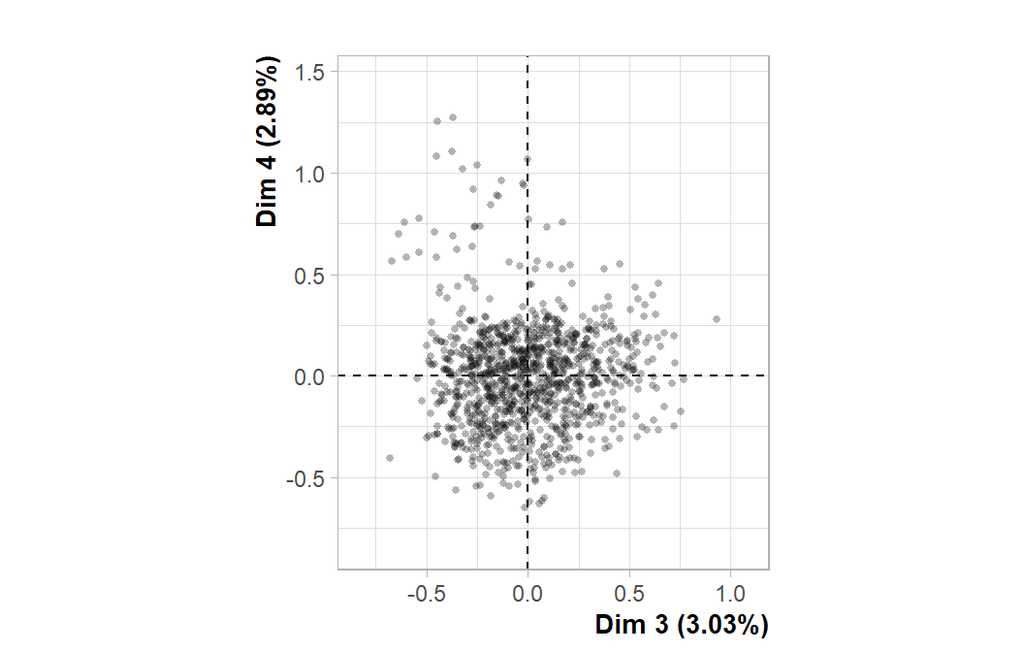

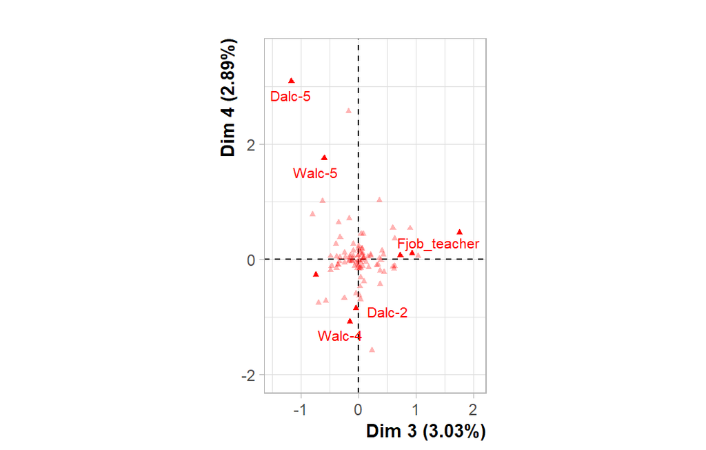

**Figure 4.2 - Graphe des variables (ACM)** *Les variables libellées sont celles les mieux représentées sur le plan.*

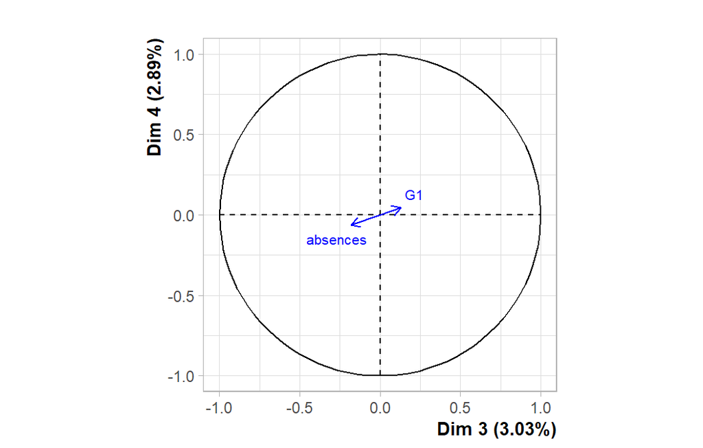

**Figure 4.3 - Graphe des variables quantitatives (ACM)** *Les variables libellées sont celles les mieux représentées sur le plan.*

La **dimension 3** oppose des individus caractérisés par une coordonnée fortement positive sur l’axe (à droite du graphe) à des individus caractérisés par une coordonnée fortement négative sur l’axe (à gauche du graphe).

Le groupe 1 (caractérisés par une coordonnée positive sur l’axe) partage :

- une forte fréquence des modalités telles que *Medu=MHigh_education*, *Fedu=FHigh_education*, *Fjob=Fjob_teacher*, *Mjob=Mjob_teacher*, *school=MS*, *address=R*, *Walc=Walc-2*, *course=portuguese*, *Fjob=Fjob_at_home* et *nursery=nurs-NO* (du plus commun au plus rare).
- une faible fréquence des modalités telles que *Medu=MSecondary_school*, *Medu=M5th_9th_grade*, *school=GP*, *Fedu=F5th_9th_grade*, *Fjob=Fjob_other*, *Fedu=FSecondary_school*, *Mjob=Mjob_other*, *address=U*, *reason=reason_home* et *goout=go_out-5* (du plus rare au plus commun).

Le groupe 2 (caractérisés par une coordonnées négative sur l’axe) partage :

- une forte fréquence des modalités telles que *Walc=Walc-5*, *Dalc=Dalc-5*, *traveltime=t60+*, *goout=go_out-5*, *failures=3*, *Medu=M5th_9th_grade*, *studytime=10+*, *freetime=freet-5*, *higher=highEdu-YES* et *Fedu=FPrimary_school* (du plus commun au plus rare).
- une faible fréquence des modalités telles que *Walc=Walc-3*, *goout=go_out-4*, *Walc=Walc-4*, *Dalc=Dalc-2*, *Walc=Walc-2*, *Fedu=FSecondary_school*, *studytime=s2-5*, *traveltime=t0-15*, *Dalc=Dalc-1* et *higher=highEdu-NO* (du plus rare au plus commun).

Le groupe 3 (caractérisés par une coordonnées négative sur l’axe) partage :

- une forte fréquence des modalités telles que *Medu=MSecondary_school*, *school=GP*, *Fedu=FSecondary_school*, *address=U*, *course=Math*, *Fjob=Fjob_other*, *internet=int-NO*, *reason=reason_home*, *Fedu=F5th_9th_grade* et *Mjob=Mjob_other* (du plus commun au plus rare).
- une faible fréquence des modalités telles que *Medu=MHigh_education*, *Fedu=FHigh_education*, *school=MS*, *Fjob=Fjob_teacher*, *address=R*, *Mjob=Mjob_teacher*, *course=portuguese*, *internet=int-YES*, *Walc=Walc-5* et *Dalc=Dalc-5* (du plus rare au plus commun).

La **dimension 4** oppose des individus caractérisés par une coordonnée fortement positive sur l’axe (en haut du graphe) à des individus caractérisés par une coordonnée fortement négative sur l’axe (en bas du graphe).

Le groupe 1 (caractérisés par une coordonnée positive sur l’axe) partage :

- une forte fréquence des modalités telles que *Walc=Walc-5*, *Dalc=Dalc-5*, *traveltime=t60+*, *goout=go_out-5*, *failures=3*, *Medu=M5th_9th_grade*, *studytime=10+*, *freetime=freet-5*, *higher=highEdu-YES* et *Fedu=FPrimary_school* (du plus commun au plus rare).
- une faible fréquence des modalités telles que *Walc=Walc-3*, *goout=go_out-4*, *Walc=Walc-4*, *Dalc=Dalc-2*, *Walc=Walc-2*, *Fedu=FSecondary_school*, *studytime=s2-5*, *traveltime=t0-15*, *Dalc=Dalc-1* et *higher=highEdu-NO* (du plus rare au plus commun).

Le groupe 2 (caractérisés par une coordonnées négative sur l’axe) partage :

- une forte fréquence des modalités telles que *Medu=MSecondary_school*, *school=GP*, *Fedu=FSecondary_school*, *address=U*, *course=Math*, *Fjob=Fjob_other*, *internet=int-NO*, *reason=reason_home*, *Fedu=F5th_9th_grade* et *Mjob=Mjob_other* (du plus commun au plus rare).
- une faible fréquence des modalités telles que *Medu=MHigh_education*, *Fedu=FHigh_education*, *school=MS*, *Fjob=Fjob_teacher*, *address=R*, *Mjob=Mjob_teacher*, *course=portuguese*, *internet=int-YES*, *Walc=Walc-5* et *Dalc=Dalc-5* (du plus rare au plus commun).

Le groupe 3 (caractérisés par une coordonnées négative sur l’axe) partage :

- une forte fréquence des modalités telles que *Medu=MHigh_education*, *Fedu=FHigh_education*, *Fjob=Fjob_teacher*, *Mjob=Mjob_teacher*, *school=MS*, *address=R*, *Walc=Walc-2*, *course=portuguese*, *Fjob=Fjob_at_home* et *nursery=nurs-NO* (du plus commun au plus rare).
- une faible fréquence des modalités telles que *Medu=MSecondary_school*, *Medu=M5th_9th_grade*, *school=GP*, *Fedu=F5th_9th_grade*, *Fjob=Fjob_other*, *Fedu=FSecondary_school*, *Mjob=Mjob_other*, *address=U*, *reason=reason_home* et *goout=go_out-5* (du plus rare au plus commun).

### 5. Description du plan 5:6

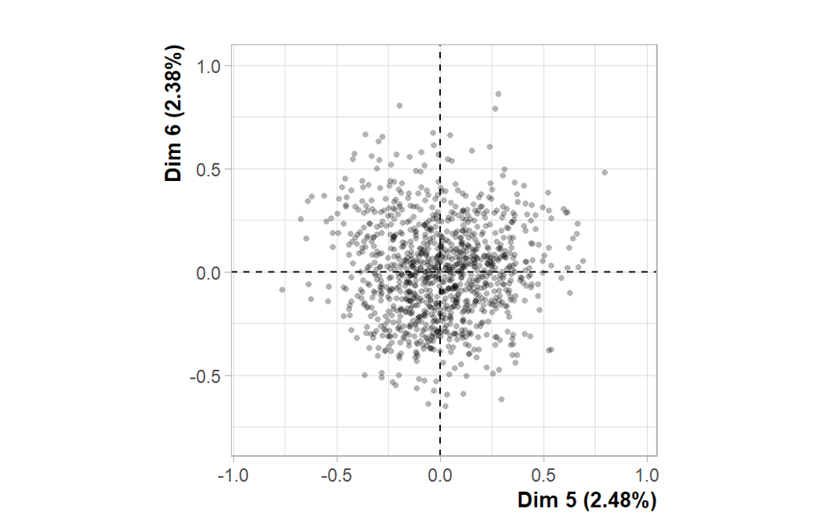

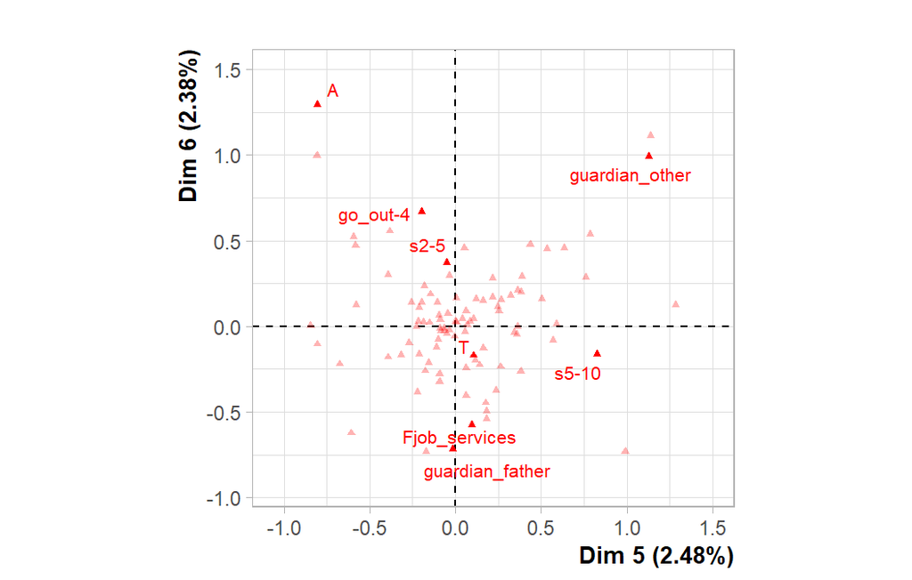

**Figure 5.2 - Graphe des variables (ACM)** *Les variables libellées sont celles les mieux représentées sur le plan.*

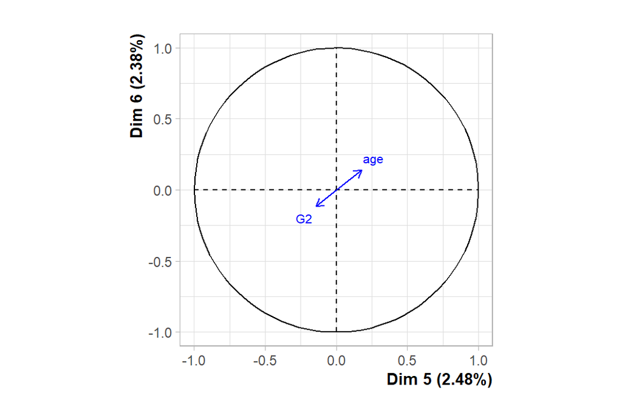

**Figure 5.3 - Graphe des variables quantitatives (ACM)** *Les variables libellées sont celles les mieux représentées sur le plan.*

La **dimension 5** oppose des individus caractérisés par une coordonnée fortement positive sur l’axe (à droite du graphe) à des individus caractérisés par une coordonnée fortement négative sur l’axe (à gauche du graphe).

Le groupe 1 (caractérisés par une coordonnée positive sur l’axe) partage :

- une forte fréquence des modalités telles que *guardian=guardian_other*, *romantic=rom-NO*, *famsup=famsup-NO*, *studytime=s5-10*, *famrel=famrel-4*, *Mjob=Mjob_at_home*, *Fedu=FPrimary_school*, *paid=paid-NO*, *course=Math* et *famsize=GT3* (du plus commun au plus rare).
- une faible fréquence des modalités telles que *romantic=rom-YES*, *famsup=famsup-YES*, *failures=0*, *freetime=freet-2*, *paid=paid-YES*, *Fedu=F5th_9th_grade*, *course=portuguese*, *famsize=LE3*, *famrel=famrel-5* et *studytime=s0-2* (du plus rare au plus commun).

Le groupe 2 (caractérisés par une coordonnées négative sur l’axe) partage :

- une forte fréquence des modalités telles que *Pstatus=A*, *famsize=LE3*, *goout=go_out-4*, *guardian=guardian_mother*, *health=health-1*, *studytime=s2-5*, *Fjob=Fjob_other*, *Walc=Walc-1*, *nursery=nurs-NO* et *course=portuguese* (du plus commun au plus rare).
- une faible fréquence des modalités telles que *Pstatus=T*, *famsize=GT3*, *studytime=s5-10*, *Walc=Walc-2*, *Fjob=Fjob_services*, *guardian=guardian_father*, *goout=go_out-3*, *nursery=nurs-YES*, *course=Math* et *health=health-3* (du plus rare au plus commun).

La **dimension 6** oppose des individus caractérisés par une coordonnée fortement positive sur l’axe (en haut du graphe) à des individus caractérisés par une coordonnée fortement négative sur l’axe (en bas du graphe).

Le groupe 1 (caractérisés par une coordonnée positive sur l’axe) partage :

- une forte fréquence des modalités telles que *guardian=guardian_other*, *romantic=rom-NO*, *famsup=famsup-NO*, *studytime=s5-10*, *famrel=famrel-4*, *Mjob=Mjob_at_home*, *Fedu=FPrimary_school*, *paid=paid-NO*, *course=Math* et *famsize=GT3* (du plus commun au plus rare).
- une faible fréquence des modalités telles que *romantic=rom-YES*, *famsup=famsup-YES*, *failures=0*, *freetime=freet-2*, *paid=paid-YES*, *Fedu=F5th_9th_grade*, *course=portuguese*, *famsize=LE3*, *famrel=famrel-5* et *studytime=s0-2* (du plus rare au plus commun).

Le groupe 2 (caractérisés par une coordonnée positive sur l’axe) partage :

- une forte fréquence des modalités telles que *Pstatus=A*, *famsize=LE3*, *goout=go_out-4*, *guardian=guardian_mother*, *health=health-1*, *studytime=s2-5*, *Fjob=Fjob_other*, *Walc=Walc-1*, *nursery=nurs-NO* et *course=portuguese* (du plus commun au plus rare).
- une faible fréquence des modalités telles que *Pstatus=T*, *famsize=GT3*, *studytime=s5-10*, *Walc=Walc-2*, *Fjob=Fjob_services*, *guardian=guardian_father*, *goout=go_out-3*, *nursery=nurs-YES*, *course=Math* et *health=health-3* (du plus rare au plus commun).

Le groupe 3 (caractérisés par une coordonnées négative sur l’axe) partage :

- une forte fréquence des modalités telles que *Pstatus=T*, *Fjob=Fjob_services*, *guardian=guardian_father*, *Walc=Walc-2*, *freetime=freet-2*, *famrel=famrel-3*, *goout=go_out-2*, *failures=0*, *studytime=s0-2* et *famsize=GT3* (du plus commun au plus rare).
- une faible fréquence des modalités telles que *Pstatus=A*, *goout=go_out-4*, *studytime=s2-5*, *Fjob=Fjob_other*, *freetime=freet-4*, *guardian=guardian_other*, *Walc=Walc-1*, *health=health-1*, *famsize=LE3* et *guardian=guardian_mother* (du plus rare au plus commun).

### 6. Description du plan 7:8

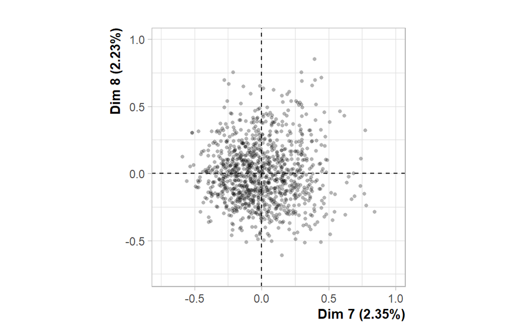

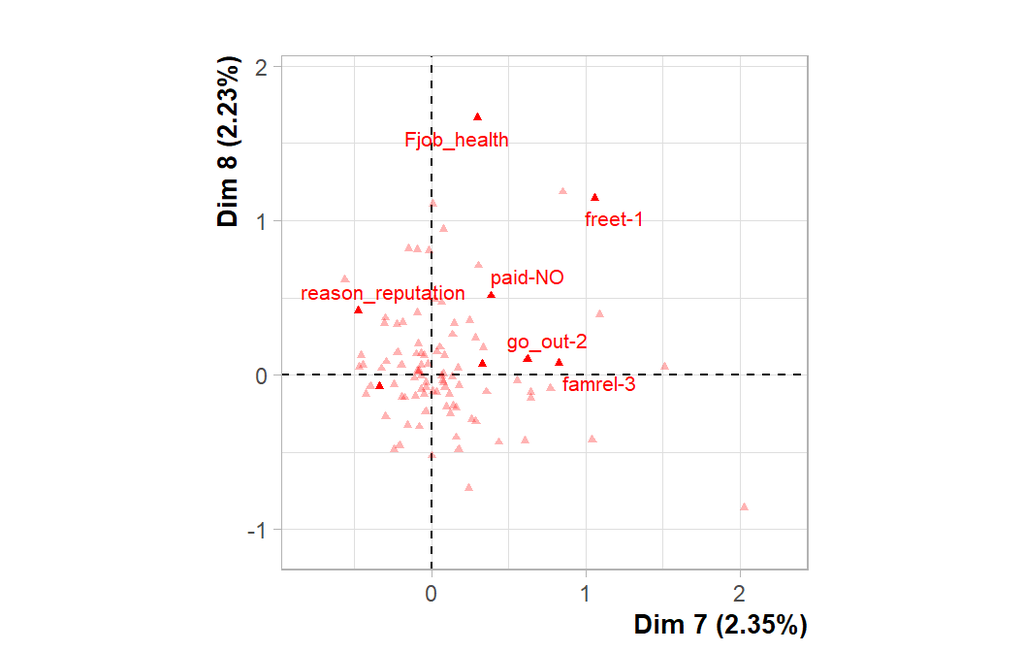

**Figure 6.2 - Graphe des variables (ACM)** *Les variables libellées sont celles les mieux représentées sur le plan.*

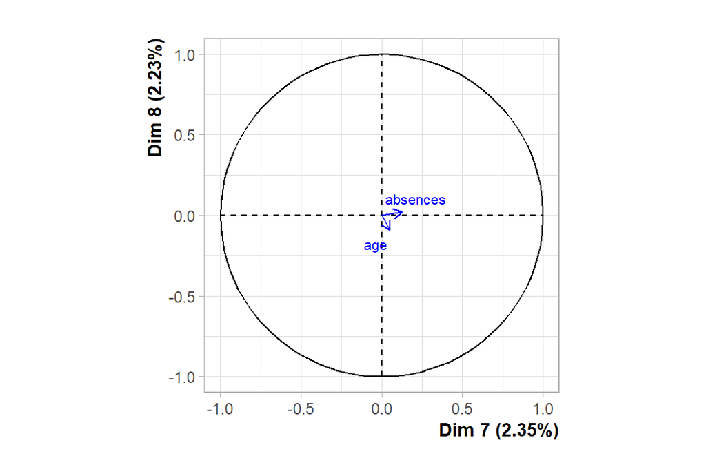

**Figure 6.3 - Graphe des variables quantitatives (ACM)** *Les variables libellées sont celles les mieux représentées sur le plan.*

La **dimension 7** oppose des individus caractérisés par une coordonnée fortement positive sur l’axe (à droite du graphe) à des individus caractérisés par une coordonnée fortement négative sur l’axe (à gauche du graphe).

Le groupe 1 (caractérisés par une coordonnée positive sur l’axe) partage :

- une forte fréquence des modalités telles que *freetime=freet-2*, *goout=go_out-2*, *famrel=famrel-3*, *activities=act-YES*, *Pstatus=A*, *address=U*, *failures=2*, *studytime=s0-2*, *reason=reason_home* et *famrel=famrel-1* (du plus commun au plus rare).
- une faible fréquence des modalités telles que *activities=act-NO*, *Pstatus=T*, *address=R*, *health=health-4*, *famrel=famrel-5*, *nursery=nurs-NO*, *reason=reason_reputation*, *Walc=Walc-3*, *Fedu=FSecondary_school* et *goout=go_out-3* (du plus rare au plus commun).

Le groupe 2 (caractérisés par une coordonnée positive sur l’axe) partage :

- une forte fréquence des modalités telles que *Fjob=Fjob_health*, *schoolsup=schsup-NO*, *freetime=freet-1*, *paid=paid-NO*, *Dalc=Dalc-3*, *course=Math*, *Medu=MPrimary_school*, *guardian=guardian_father*, *Walc=Walc-5* et *internet=int-YES* (du plus commun au plus rare).
- une faible fréquence des modalités telles que *schoolsup=schsup-YES*, *paid=paid-YES*, *reason=reason_course*, *course=portuguese*, *guardian=guardian_mother*, *Mjob=Mjob_services*, *internet=int-NO*, *romantic=rom-NO*, *Walc=Walc-2* et *higher=highEdu-YES* (du plus rare au plus commun).

Le groupe 3 (caractérisés par une coordonnées négative sur l’axe) partage :

- une forte fréquence des modalités telles que *activities=act-NO*, *course=portuguese*, *paid=paid-YES*, *reason=reason_course*, *studytime=s5-10*, *internet=int-NO*, *freetime=freet-3*, *schoolsup=schsup-YES*, *guardian=guardian_mother* et *famrel=famrel-5* (du plus commun au plus rare).
- une faible fréquence des modalités telles que *activities=act-YES*, *freetime=freet-1*, *famrel=famrel-3*, *course=Math*, *paid=paid-NO*, *goout=go_out-2*, *Fjob=Fjob_health*, *freetime=freet-2*, *internet=int-YES* et *health=health-3* (du plus rare au plus commun).

La **dimension 8** oppose des individus caractérisés par une coordonnée fortement positive sur l’axe (en haut du graphe) à des individus caractérisés par une coordonnée fortement négative sur l’axe (en bas du graphe).

Le groupe 1 (caractérisés par une coordonnée positive sur l’axe) partage :

- une forte fréquence des modalités telles que *Fjob=Fjob_health*, *schoolsup=schsup-NO*, *freetime=freet-1*, *paid=paid-NO*, *Dalc=Dalc-3*, *course=Math*, *Medu=MPrimary_school*, *guardian=guardian_father*, *Walc=Walc-5* et *internet=int-YES* (du plus commun au plus rare).
- une faible fréquence des modalités telles que *schoolsup=schsup-YES*, *paid=paid-YES*, *reason=reason_course*, *course=portuguese*, *guardian=guardian_mother*, *Mjob=Mjob_services*, *internet=int-NO*, *romantic=rom-NO*, *Walc=Walc-2* et *higher=highEdu-YES* (du plus rare au plus commun).

Le groupe 2 (caractérisés par une coordonnées négative sur l’axe) partage :

- une forte fréquence des modalités telles que *activities=act-NO*, *course=portuguese*, *paid=paid-YES*, *reason=reason_course*, *studytime=s5-10*, *internet=int-NO*, *freetime=freet-3*, *schoolsup=schsup-YES*, *guardian=guardian_mother* et *famrel=famrel-5* (du plus commun au plus rare).
- une faible fréquence des modalités telles que *activities=act-YES*, *freetime=freet-1*, *famrel=famrel-3*, *course=Math*, *paid=paid-NO*, *goout=go_out-2*, *Fjob=Fjob_health*, *freetime=freet-2*, *internet=int-YES* et *health=health-3* (du plus rare au plus commun).

Le groupe 3 (caractérisés par une coordonnées négative sur l’axe) partage :

- une forte fréquence des modalités telles que *freetime=freet-2*, *goout=go_out-2*, *famrel=famrel-3*, *activities=act-YES*, *Pstatus=A*, *address=U*, *failures=2*, *studytime=s0-2*, *reason=reason_home* et *famrel=famrel-1* (du plus commun au plus rare).
- une faible fréquence des modalités telles que *activities=act-NO*, *Pstatus=T*, *address=R*, *health=health-4*, *famrel=famrel-5*, *nursery=nurs-NO*, *reason=reason_reputation*, *Walc=Walc-3*, *Fedu=FSecondary_school* et *goout=go_out-3* (du plus rare au plus commun).

### 7. Description du plan 9:10

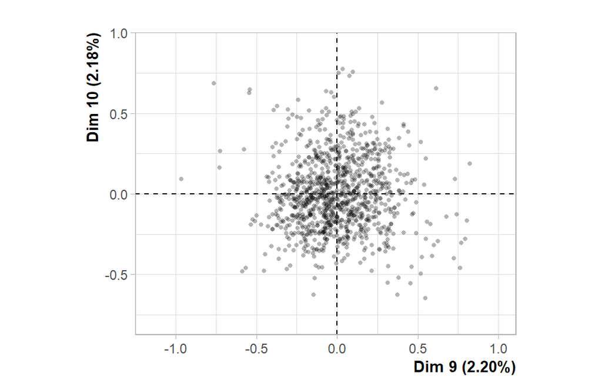

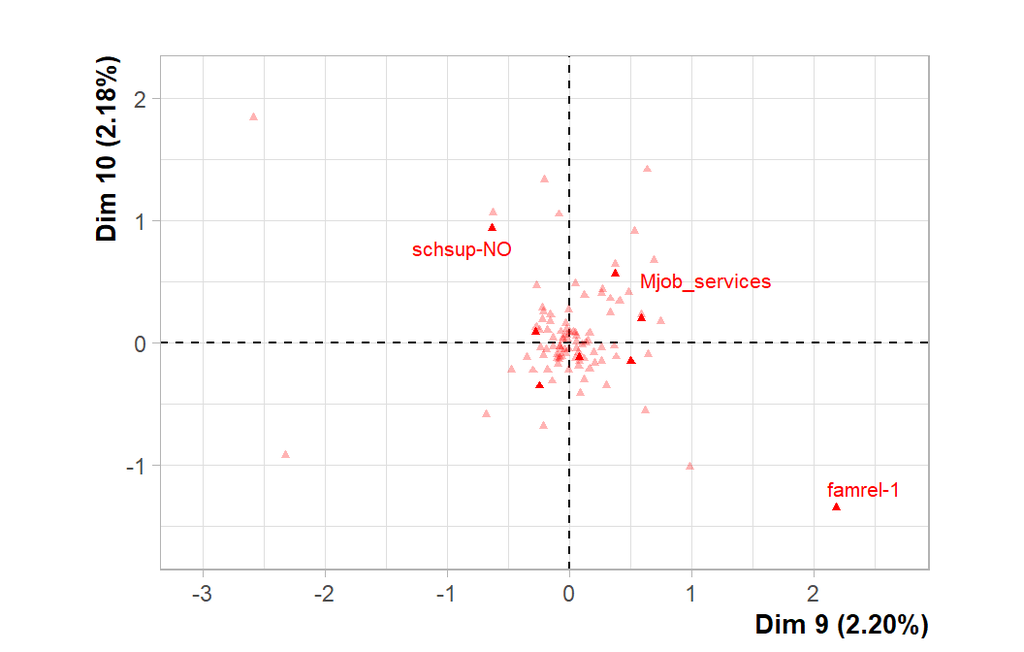

**Figure 7.2 - Graphe des variables (ACM)** *Les variables libellées sont celles les mieux représentées sur le plan.*

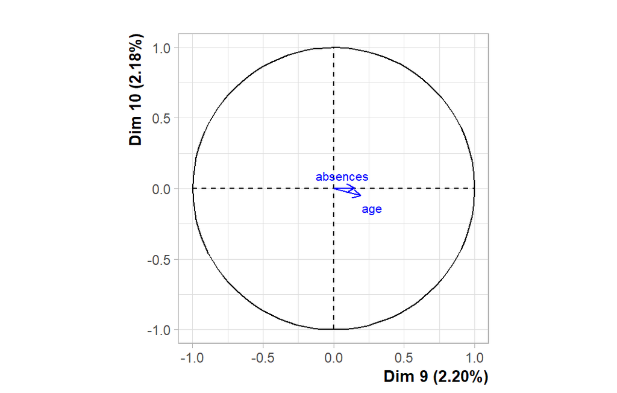

**Figure 7.3 - Graphe des variables quantitatives (ACM)** *Les variables libellées sont celles les mieux représentées sur le plan.*

La **dimension 9** oppose des individus caractérisés par une coordonnée fortement positive sur l’axe (à droite du graphe) à des individus caractérisés par une coordonnée fortement négative sur l’axe (à gauche du graphe).

Le groupe 1 (caractérisés par une coordonnée positive sur l’axe) partage :

- une forte fréquence des modalités telles que *romantic=rom-NO*, *Fjob=Fjob_services*, *famrel=famrel-1*, *freetime=freet-2*, *schoolsup=schsup-YES*, *health=health-1*, *guardian=guardian_other*, *Fedu=FSecondary_school*, *sex=F* et *school=MS* (du plus commun au plus rare).
- une faible fréquence des modalités telles que *romantic=rom-YES*, *freetime=freet-4*, *schoolsup=schsup-NO*, *Fjob=Fjob_other*, *Walc=Walc-1*, *health=health-5*, *health=health-4*, *sex=M*, *school=GP* et *Pstatus=T* (du plus rare au plus commun).

Le groupe 2 (caractérisés par une coordonnées négative sur l’axe) partage :

- une forte fréquence des modalités telles que *Fjob=Fjob_other*, *freetime=freet-4*, *failures=0*, *guardian=guardian_mother*, *romantic=rom-YES*, *Pstatus=T*, *higher=highEdu-NO*, *Mjob=Mjob_teacher*, *Mjob=Mjob_other* et *sex=M* (du plus commun au plus rare).
- une faible fréquence des modalités telles que *Fjob=Fjob_services*, *Mjob=Mjob_services*, *goout=go_out-1*, *freetime=freet-2*, *romantic=rom-NO*, *health=health-2*, *Medu=MSecondary_school*, *Pstatus=A*, *higher=highEdu-YES* et *guardian=guardian_other* (du plus rare au plus commun).

Le groupe 3 (caractérisés par une coordonnées négative sur l’axe) partage :

- une forte fréquence des modalités telles que *schoolsup=schsup-NO*, *Walc=Walc-1*, *Fjob=Fjob_health*, *guardian=guardian_father*, *Fjob=Fjob_at_home*, *goout=go_out-1*, *failures=3*, *romantic=rom-YES*, *Medu=MNone* et *freetime=freet-5* (du plus commun au plus rare).
- une faible fréquence des modalités telles que *schoolsup=schsup-YES*, *Fjob=Fjob_other*, *guardian=guardian_mother*, *Walc=Walc-2*, *Mjob=Mjob_other*, *romantic=rom-NO*, *failures=0*, *reason=reason_reputation*, *health=health-1* et *Mjob=Mjob_teacher* (du plus rare au plus commun).

La **dimension 10** oppose des individus caractérisés par une coordonnée fortement positive sur l’axe (en haut du graphe) à des individus caractérisés par une coordonnée fortement négative sur l’axe (en bas du graphe).

Le groupe 1 (caractérisés par une coordonnée positive sur l’axe) partage :

- une forte fréquence des modalités telles que *schoolsup=schsup-NO*, *Walc=Walc-1*, *Fjob=Fjob_health*, *guardian=guardian_father*, *Fjob=Fjob_at_home*, *goout=go_out-1*, *failures=3*, *romantic=rom-YES*, *Medu=MNone* et *freetime=freet-5* (du plus commun au plus rare).
- une faible fréquence des modalités telles que *schoolsup=schsup-YES*, *Fjob=Fjob_other*, *guardian=guardian_mother*, *Walc=Walc-2*, *Mjob=Mjob_other*, *romantic=rom-NO*, *failures=0*, *reason=reason_reputation*, *health=health-1* et *Mjob=Mjob_teacher* (du plus rare au plus commun).

Le groupe 2 (caractérisés par une coordonnées négative sur l’axe) partage :

- une forte fréquence des modalités telles que *romantic=rom-NO*, *Fjob=Fjob_services*, *famrel=famrel-1*, *freetime=freet-2*, *schoolsup=schsup-YES*, *health=health-1*, *guardian=guardian_other*, *Fedu=FSecondary_school*, *sex=F* et *school=MS* (du plus commun au plus rare).
- une faible fréquence des modalités telles que *romantic=rom-YES*, *freetime=freet-4*, *schoolsup=schsup-NO*, *Fjob=Fjob_other*, *Walc=Walc-1*, *health=health-5*, *health=health-4*, *sex=M*, *school=GP* et *Pstatus=T* (du plus rare au plus commun).

Le groupe 3 (caractérisés par une coordonnées négative sur l’axe) partage :

- une forte fréquence des modalités telles que *Fjob=Fjob_other*, *freetime=freet-4*, *failures=0*, *guardian=guardian_mother*, *romantic=rom-YES*, *Pstatus=T*, *higher=highEdu-NO*, *Mjob=Mjob_teacher*, *Mjob=Mjob_other* et *sex=M* (du plus commun au plus rare).
- une faible fréquence des modalités telles que *Fjob=Fjob_services*, *Mjob=Mjob_services*, *goout=go_out-1*, *freetime=freet-2*, *romantic=rom-NO*, *health=health-2*, *Medu=MSecondary_school*, *Pstatus=A*, *higher=highEdu-YES* et *guardian=guardian_other* (du plus rare au plus commun).

### 8. Description du plan 11:12

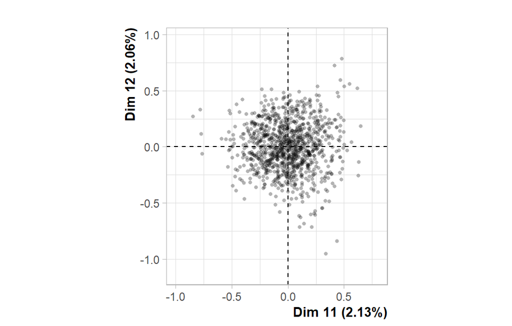

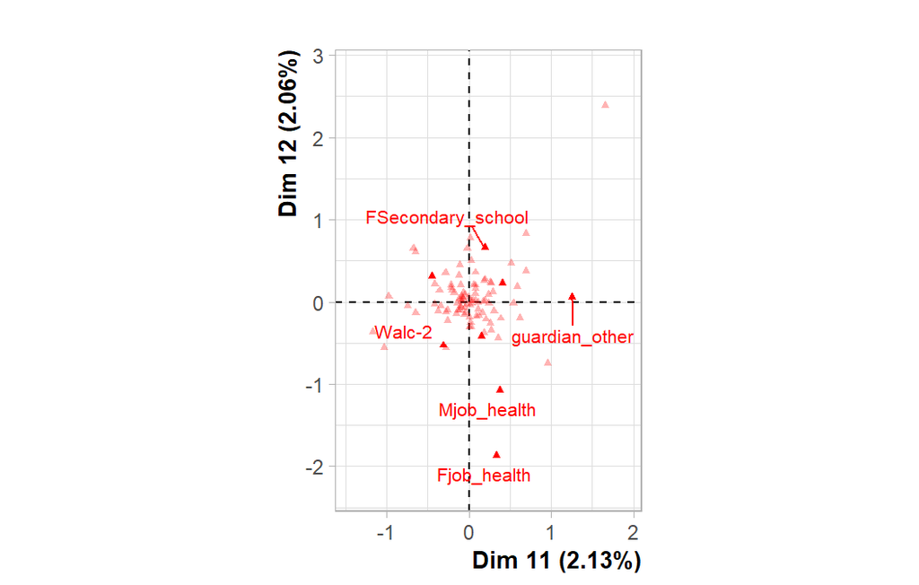

**Figure 8.2 - Graphe des variables (ACM)** *Les variables libellées sont celles les mieux représentées sur le plan.*

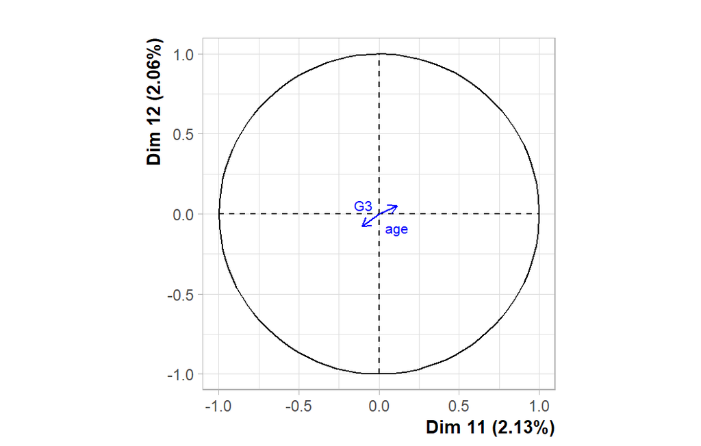

**Figure 8.3 - Graphe des variables quantitatives (ACM)** *Les variables libellées sont celles les mieux représentées sur le plan.*

La **dimension 11** oppose des individus caractérisés par une coordonnée fortement positive sur l’axe (à droite du graphe) à des individus caractérisés par une coordonnée fortement négative sur l’axe (à gauche du graphe).

Le groupe 1 (caractérisés par une coordonnée positive sur l’axe) partage :

- une forte fréquence des modalités telles que *Walc=Walc-1*, *Fedu=FSecondary_school*, *guardian=guardian_other*, *activities=act-NO*, *course=Math*, *Dalc=Dalc-1*, *freetime=freet-5*, *goout=go_out-1*, *Mjob=Mjob_teacher* et *famsize=GT3* (du plus commun au plus rare).
- une faible fréquence des modalités telles que *Walc=Walc-2*, *Dalc=Dalc-2*, *activities=act-YES*, *course=portuguese*, *Fedu=F5th_9th_grade*, *failures=0*, *famsize=LE3*, *traveltime=t0-15*, *Fjob=Fjob_health* et *health=health-5* (du plus rare au plus commun).

Le groupe 2 (caractérisés par une coordonnée positive sur l’axe) partage :

- une forte fréquence des modalités telles que *health=health-5*, *Mjob=Mjob_health*, *Fjob=Fjob_health*, *Fedu=FHigh_education*, *Walc=Walc-2*, *freetime=freet-4*, *freetime=freet-2*, *famsup=famsup-NO*, *goout=go_out-2* et *traveltime=t0-15* (du plus commun au plus rare).
- une faible fréquence des modalités telles que *Fedu=FSecondary_school*, *goout=go_out-3*, *Mjob=Mjob_teacher*, *Mjob=Mjob_at_home*, *freetime=freet-3*, *health=health-2*, *health=health-3*, *famsup=famsup-YES*, *goout=go_out-1* et *guardian=guardian_other* (du plus rare au plus commun).

Le groupe 3 (caractérisés par une coordonnées négative sur l’axe) partage :

- une forte fréquence des modalités telles que *Dalc=Dalc-2*, *goout=go_out-3*, *famsize=LE3*, *freetime=freet-3*, *activities=act-YES*, *failures=0*, *reason=reason_home*, *course=portuguese*, *freetime=freet-1* et *Fedu=F5th_9th_grade* (du plus commun au plus rare).
- une faible fréquence des modalités telles que *Walc=Walc-1*, *Dalc=Dalc-1*, *famsize=GT3*, *activities=act-NO*, *famrel=famrel-5*, *reason=reason_reputation*, *course=Math*, *guardian=guardian_other*, *failures=1* et *freetime=freet-2* (du plus rare au plus commun).

La **dimension 12** oppose des individus caractérisés par une coordonnée fortement positive sur l’axe (en haut du graphe) à des individus caractérisés par une coordonnée fortement négative sur l’axe (en bas du graphe).

Le groupe 1 (caractérisés par une coordonnée positive sur l’axe) partage :

- une forte fréquence des modalités telles que *Walc=Walc-1*, *Fedu=FSecondary_school*, *guardian=guardian_other*, *activities=act-NO*, *course=Math*, *Dalc=Dalc-1*, *freetime=freet-5*, *goout=go_out-1*, *Mjob=Mjob_teacher* et *famsize=GT3* (du plus commun au plus rare).
- une faible fréquence des modalités telles que *Walc=Walc-2*, *Dalc=Dalc-2*, *activities=act-YES*, *course=portuguese*, *Fedu=F5th_9th_grade*, *failures=0*, *famsize=LE3*, *traveltime=t0-15*, *Fjob=Fjob_health* et *health=health-5* (du plus rare au plus commun).

Le groupe 2 (caractérisés par une coordonnées négative sur l’axe) partage :

- une forte fréquence des modalités telles que *health=health-5*, *Mjob=Mjob_health*, *Fjob=Fjob_health*, *Fedu=FHigh_education*, *Walc=Walc-2*, *freetime=freet-4*, *freetime=freet-2*, *famsup=famsup-NO*, *goout=go_out-2* et *traveltime=t0-15* (du plus commun au plus rare).
- une faible fréquence des modalités telles que *Fedu=FSecondary_school*, *goout=go_out-3*, *Mjob=Mjob_teacher*, *Mjob=Mjob_at_home*, *freetime=freet-3*, *health=health-2*, *health=health-3*, *famsup=famsup-YES*, *goout=go_out-1* et *guardian=guardian_other* (du plus rare au plus commun).

### 9. Description du plan 13:14

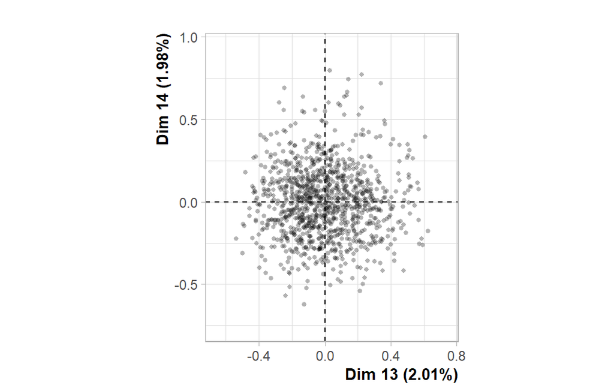

**Figure 9.1 - Graphe des individus (ACM)** *Les individus libellés sont ceux ayant la plus grande contribution à la construction du plan.*

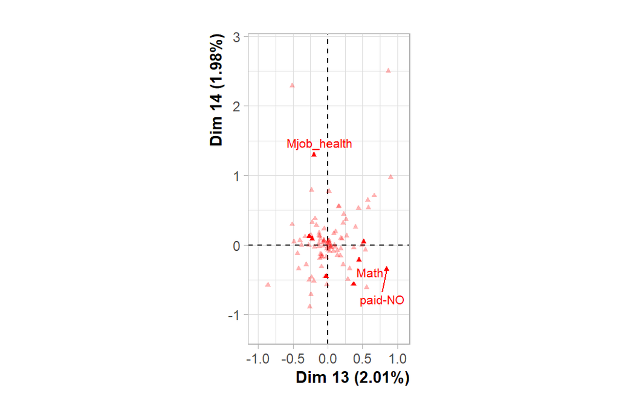

**Figure 9.2 - Graphe des variables (ACM)** *Les variables libellées sont celles les mieux représentées sur le plan.*

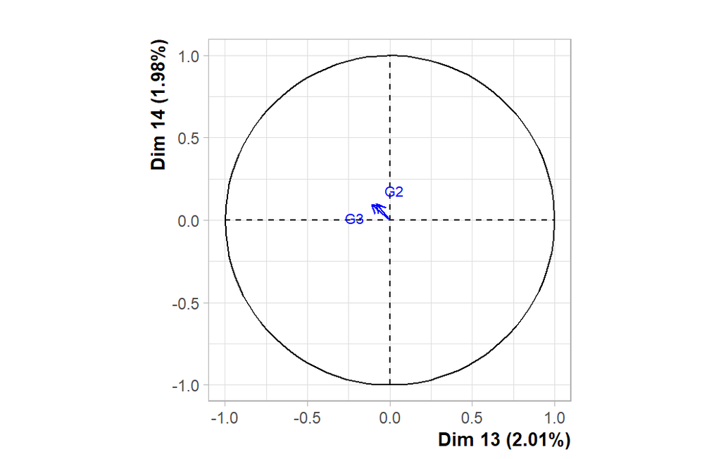

**Figure 9.3 - Graphe des variables quantitatives (ACM)** *Les variables libellées sont celles les mieux représentées sur le plan.*

La **dimension 13** oppose des individus caractérisés par une coordonnée fortement positive sur l’axe (à droite du graphe) à des individus caractérisés par une coordonnée fortement négative sur l’axe (à gauche du graphe).

Le groupe 1 (caractérisés par une coordonnée positive sur l’axe) partage :

- une forte fréquence des modalités telles que *paid=paid-NO*, *Fedu=F5th_9th_grade*, *Medu=M5th_9th_grade*, *course=Math*, *guardian=guardian_mother*, *Dalc=Dalc-2*, *traveltime=t15-30*, *nursery=nurs-NO*, *romantic=rom-YES* et *Mjob=Mjob_services* (du plus commun au plus rare).
- une faible fréquence des modalités telles que *paid=paid-YES*, *course=portuguese*, *Fedu=FSecondary_school*, *guardian=guardian_father*, *nursery=nurs-YES*, *traveltime=t0-15*, *reason=reason_home*, *Mjob=Mjob_other*, *romantic=rom-NO* et *address=U* (du plus rare au plus commun).

Le groupe 2 (caractérisés par une coordonnées négative sur l’axe) partage :

- une forte fréquence des modalités telles que *paid=paid-YES*, *course=portuguese*, *address=U*, *Fedu=FSecondary_school*, *Mjob=Mjob_health*, *health=health-3*, *romantic=rom-NO*, *Mjob=Mjob_other*, *nursery=nurs-YES* et *internet=int-NO* (du plus commun au plus rare).
- une faible fréquence des modalités telles que *paid=paid-NO*, *Mjob=Mjob_services*, *course=Math*, *address=R*, *guardian=guardian_mother*, *health=health-5*, *Fedu=F5th_9th_grade*, *Medu=M5th_9th_grade*, *romantic=rom-YES* et *goout=go_out-1* (du plus rare au plus commun).

Le groupe 3 (caractérisés par une coordonnées négative sur l’axe) partage :

- une forte fréquence des modalités telles que *health=health-5*, *Medu=MSecondary_school*, *Fedu=FHigh_education*, *Fjob=Fjob_teacher*, *famsize=GT3*, *famrel=famrel-5*, *Mjob=Mjob_services*, *failures=1*, *traveltime=t60+* et *schoolsup=schsup-NO* (du plus commun au plus rare).
- une faible fréquence des modalités telles que *reason=reason_reputation*, *traveltime=t15-30*, *Fedu=F5th_9th_grade*, *Medu=M5th_9th_grade*, *famsize=LE3*, *Mjob=Mjob_health*, *health=health-4*, *health=health-3*, *studytime=10+* et *famrel=famrel-3* (du plus rare au plus commun).

La **dimension 14** oppose des individus caractérisés par une coordonnée fortement positive sur l’axe (en haut du graphe) à des individus caractérisés par une coordonnée fortement négative sur l’axe (en bas du graphe).

Le groupe 1 (caractérisés par une coordonnée positive sur l’axe) partage :

- une forte fréquence des modalités telles que *paid=paid-YES*, *course=portuguese*, *address=U*, *Fedu=FSecondary_school*, *Mjob=Mjob_health*, *health=health-3*, *romantic=rom-NO*, *Mjob=Mjob_other*, *nursery=nurs-YES* et *internet=int-NO* (du plus commun au plus rare).
- une faible fréquence des modalités telles que *paid=paid-NO*, *Mjob=Mjob_services*, *course=Math*, *address=R*, *guardian=guardian_mother*, *health=health-5*, *Fedu=F5th_9th_grade*, *Medu=M5th_9th_grade*, *romantic=rom-YES* et *goout=go_out-1* (du plus rare au plus commun).

Le groupe 2 (caractérisés par une coordonnées négative sur l’axe) partage :

- une forte fréquence des modalités telles que *health=health-5*, *Medu=MSecondary_school*, *Fedu=FHigh_education*, *Fjob=Fjob_teacher*, *famsize=GT3*, *famrel=famrel-5*, *Mjob=Mjob_services*, *failures=1*, *traveltime=t60+* et *schoolsup=schsup-NO* (du plus commun au plus rare).
- une faible fréquence des modalités telles que *reason=reason_reputation*, *traveltime=t15-30*, *Fedu=F5th_9th_grade*, *Medu=M5th_9th_grade*, *famsize=LE3*, *Mjob=Mjob_health*, *health=health-4*, *health=health-3*, *studytime=10+* et *famrel=famrel-3* (du plus rare au plus commun).

Le groupe 3 (caractérisés par une coordonnées négative sur l’axe) partage :

- une forte fréquence des modalités telles que *paid=paid-NO*, *Fedu=F5th_9th_grade*, *Medu=M5th_9th_grade*, *course=Math*, *guardian=guardian_mother*, *Dalc=Dalc-2*, *traveltime=t15-30*, *nursery=nurs-NO*, *romantic=rom-YES* et *Mjob=Mjob_services* (du plus commun au plus rare).
- une faible fréquence des modalités telles que *paid=paid-YES*, *course=portuguese*, *Fedu=FSecondary_school*, *guardian=guardian_father*, *nursery=nurs-YES*, *traveltime=t0-15*, *reason=reason_home*, *Mjob=Mjob_other*, *romantic=rom-NO* et *address=U* (du plus rare au plus commun).

### 10. Description du plan 15:16

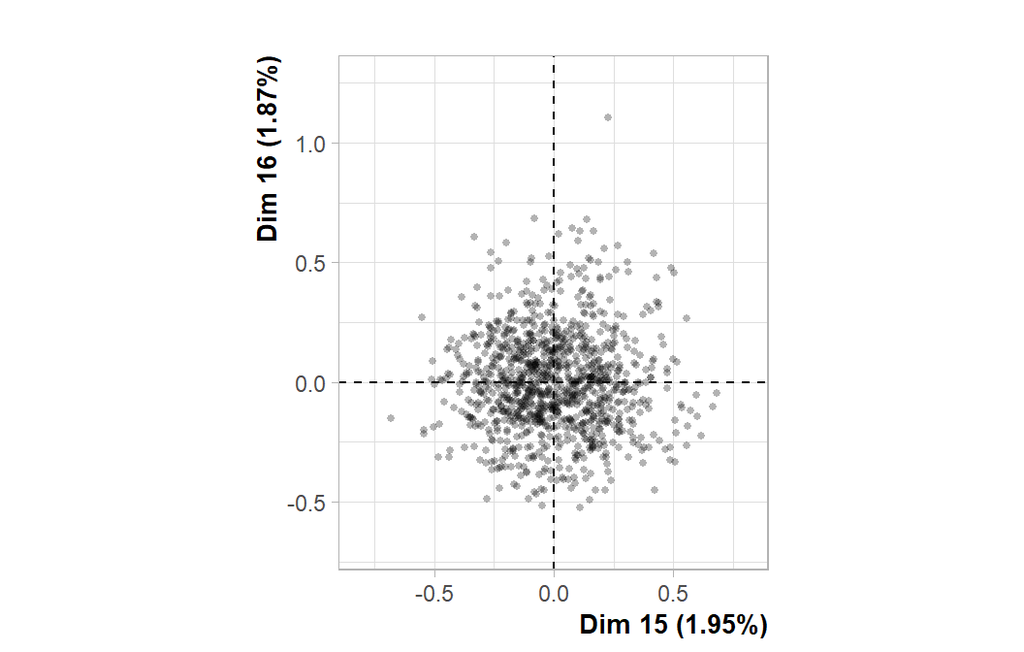

**Figure 10.1 - Graphe des individus (ACM)** *Les individus libellés sont ceux ayant la plus grande contribution à la construction du plan.*

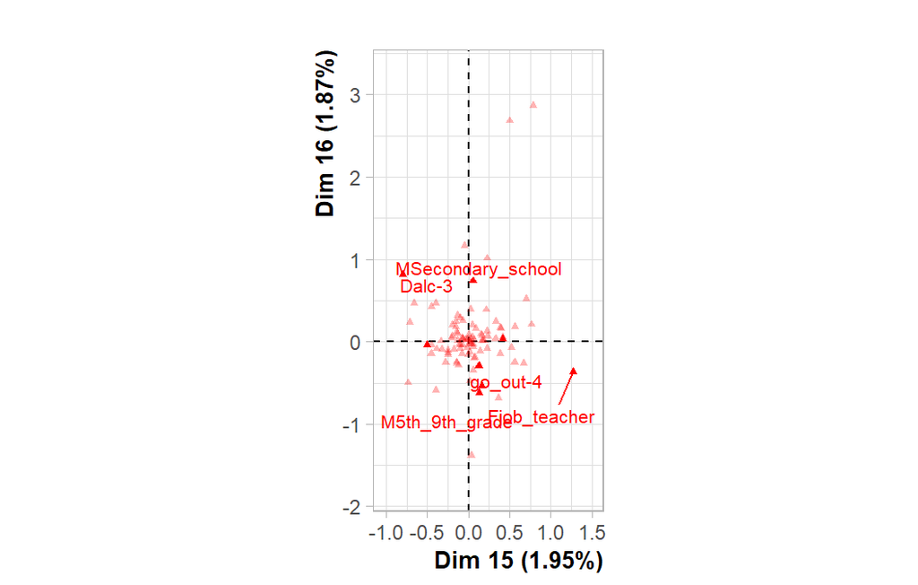

**Figure 10.2 - Graphe des variables (ACM)** *Les variables libellées sont celles les mieux représentées sur le plan.*

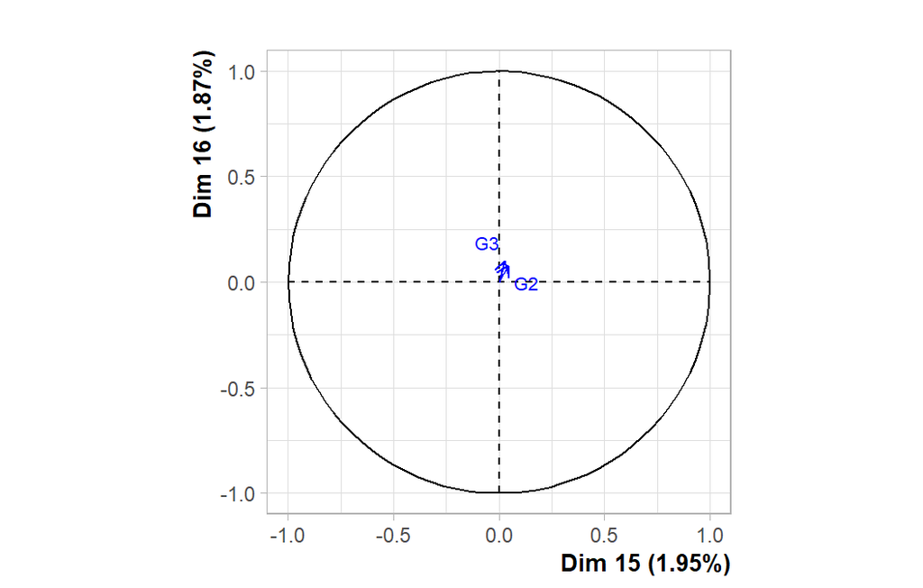

**Figure 10.3 - Graphe des variables quantitatives (ACM)** *Les variables libellées sont celles les mieux représentées sur le plan.*

La **dimension 15** oppose des individus caractérisés par une coordonnée fortement positive sur l’axe (à droite du graphe) à des individus caractérisés par une coordonnée fortement négative sur l’axe (à gauche du graphe).

Le groupe 1 (caractérisés par une coordonnée positive sur l’axe) partage :

- une forte fréquence des modalités telles que *Dalc=Dalc-2*, *Mjob=Mjob_other*, *traveltime=t15-30*, *Fjob=Fjob_teacher*, *Walc=Walc-3*, *famsup=famsup-NO*, *famsize=GT3*, *nursery=nurs-YES*, *course=portuguese* et *address=R* (du plus commun au plus rare).
- une faible fréquence des modalités telles que *famrel=famrel-5*, *traveltime=t0-15*, *Fjob=Fjob_services*, *famsup=famsup-YES*, *famsize=LE3*, *nursery=nurs-NO*, *course=Math*, *address=U*, *Mjob=Mjob_at_home* et *Dalc=Dalc-1* (du plus rare au plus commun).

Le groupe 2 (caractérisés par une coordonnées négative sur l’axe) partage :

- une forte fréquence des modalités telles que *Medu=M5th_9th_grade*, *famsup=famsup-YES*, *studytime=s2-5*, *goout=go_out-4*, *address=U*, *failures=1*, *goout=go_out-1*, *school=GP*, *Fedu=FPrimary_school* et *freetime=freet-4* (du plus commun au plus rare).
- une faible fréquence des modalités telles que *Medu=MSecondary_school*, *famsup=famsup-NO*, *address=R*, *studytime=s5-10*, *Fedu=FHigh_education*, *Medu=MHigh_education*, *school=MS*, *Mjob=Mjob_teacher*, *freetime=freet-3* et *goout=go_out-3* (du plus rare au plus commun).

Le groupe 3 (caractérisés par une coordonnées négative sur l’axe) partage :

- une forte fréquence des modalités telles que *famrel=famrel-5*, *Dalc=Dalc-3*, *studytime=s5-10*, *goout=go_out-3*, *freetime=freet-3*, *Fjob=Fjob_services*, *traveltime=t0-15*, *health=health-5*, *Fjob=Fjob_at_home* et *reason=reason_course* (du plus commun au plus rare).
- une faible fréquence des modalités telles que *Medu=M5th_9th_grade*, *Dalc=Dalc-2*, *studytime=s2-5*, *Fjob=Fjob_other*, *Mjob=Mjob_other*, *health=health-2*, *Fjob=Fjob_teacher*, *goout=go_out-4*, *traveltime=t15-30* et *nursery=nurs-YES* (du plus rare au plus commun).

La **dimension 16** oppose des individus caractérisés par une coordonnée fortement positive sur l’axe (en haut du graphe) à des individus caractérisés par une coordonnée fortement négative sur l’axe (en bas du graphe).

Le groupe 1 (caractérisés par une coordonnée positive sur l’axe) partage :

- une forte fréquence des modalités telles que *famrel=famrel-5*, *Dalc=Dalc-3*, *studytime=s5-10*, *goout=go_out-3*, *freetime=freet-3*, *Fjob=Fjob_services*, *traveltime=t0-15*, *health=health-5*, *Fjob=Fjob_at_home* et *reason=reason_course* (du plus commun au plus rare).
- une faible fréquence des modalités telles que *Medu=M5th_9th_grade*, *Dalc=Dalc-2*, *studytime=s2-5*, *Fjob=Fjob_other*, *Mjob=Mjob_other*, *health=health-2*, *Fjob=Fjob_teacher*, *goout=go_out-4*, *traveltime=t15-30* et *nursery=nurs-YES* (du plus rare au plus commun).

Le groupe 2 (caractérisés par une coordonnée positive sur l’axe) partage :

- une forte fréquence des modalités telles que *Dalc=Dalc-2*, *Mjob=Mjob_other*, *traveltime=t15-30*, *Fjob=Fjob_teacher*, *Walc=Walc-3*, *famsup=famsup-NO*, *famsize=GT3*, *nursery=nurs-YES*, *course=portuguese* et *address=R* (du plus commun au plus rare).
- une faible fréquence des modalités telles que *famrel=famrel-5*, *traveltime=t0-15*, *Fjob=Fjob_services*, *famsup=famsup-YES*, *famsize=LE3*, *nursery=nurs-NO*, *course=Math*, *address=U*, *Mjob=Mjob_at_home* et *Dalc=Dalc-1* (du plus rare au plus commun).

Le groupe 3 (caractérisés par une coordonnées négative sur l’axe) partage :

- une forte fréquence des modalités telles que *Medu=M5th_9th_grade*, *famsup=famsup-YES*, *studytime=s2-5*, *goout=go_out-4*, *address=U*, *failures=1*, *goout=go_out-1*, *school=GP*, *Fedu=FPrimary_school* et *freetime=freet-4* (du plus commun au plus rare).
- une faible fréquence des modalités telles que *Medu=MSecondary_school*, *famsup=famsup-NO*, *address=R*, *studytime=s5-10*, *Fedu=FHigh_education*, *Medu=MHigh_education*, *school=MS*, *Mjob=Mjob_teacher*, *freetime=freet-3* et *goout=go_out-3* (du plus rare au plus commun).

### 11. Description du plan 17:18

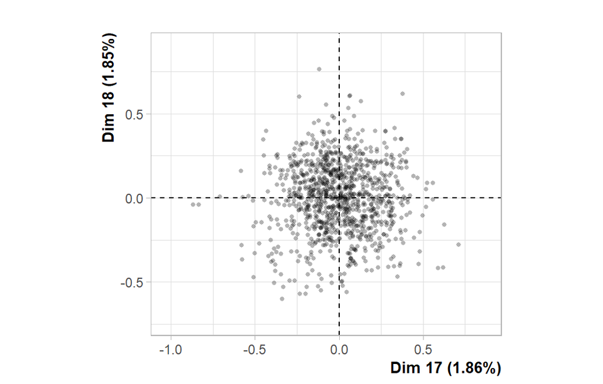

**Figure 11.1 - Graphe des individus (ACM)** *Les individus libellés sont ceux ayant la plus grande contribution à la construction du plan.*

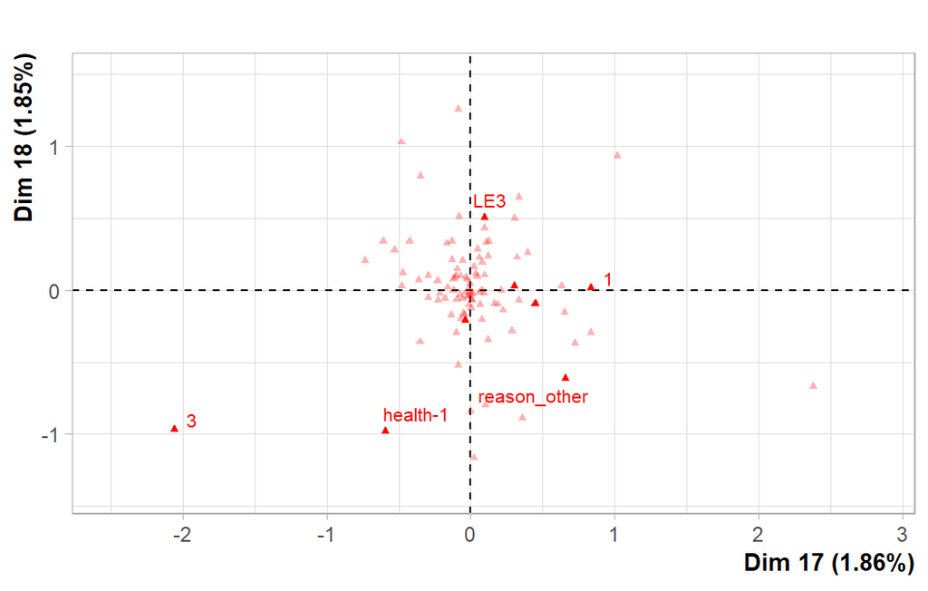

**Figure 11.2 - Graphe des variables (ACM)** *Les variables libellées sont celles les mieux représentées sur le plan.*

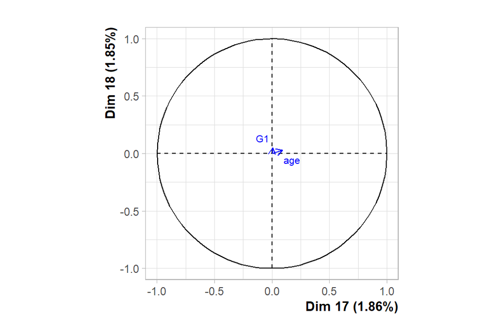

**Figure 11.3 - Graphe des variables quantitatives (ACM)** *Les variables libellées sont celles les mieux représentées sur le plan.*

La **dimension 17** oppose des individus caractérisés par une coordonnée fortement positive sur l’axe (à droite du graphe) à des individus caractérisés par une coordonnée fortement négative sur l’axe (à gauche du graphe).

Le groupe 1 (caractérisés par une coordonnée positive sur l’axe) partage :

- une forte fréquence des modalités telles que *studytime=s5-10*, *school=MS*, *reason=reason_other*, *famrel=famrel-4*, *activities=act-YES*, *nursery=nurs-NO*, *romantic=rom-NO*, *Walc=Walc-1*, *freetime=freet-1* et *failures=1* (du plus commun au plus rare).
- une faible fréquence des modalités telles que *school=GP*, *Fedu=FPrimary_school*, *famrel=famrel-3*, *activities=act-NO*, *freetime=freet-2*, *nursery=nurs-YES*, *romantic=rom-YES*, *studytime=s2-5*, *Walc=Walc-2* et *freetime=freet-3* (du plus rare au plus commun).

Le groupe 2 (caractérisés par une coordonnée positive sur l’axe) partage :

- une forte fréquence des modalités telles que *famsize=LE3*, *sex=M*, *Mjob=Mjob_services*, *health=health-4*, *traveltime=t15-30*, *Medu=M5th_9th_grade*, *Pstatus=A*, *activities=act-NO*, *Fjob=Fjob_teacher* et *failures=2* (du plus commun au plus rare).
- une faible fréquence des modalités telles que *famsize=GT3*, *health=health-1*, *sex=F*, *traveltime=t0-15*, *Pstatus=T*, *activities=act-YES*, *Mjob=Mjob_health*, *guardian=guardian_mother*, *goout=go_out-5* et *failures=3* (du plus rare au plus commun).

Le groupe 3 (caractérisés par une coordonnées négative sur l’axe) partage :

- une forte fréquence des modalités telles que *health=health-1*, *failures=3*, *Fedu=FPrimary_school*, *nursery=nurs-YES*, *Medu=MPrimary_school*, *famrel=famrel-3*, *freetime=freet-2*, *studytime=s2-5*, *Walc=Walc-2* et *traveltime=t30-60* (du plus commun au plus rare).
- une faible fréquence des modalités telles que *studytime=s5-10*, *famrel=famrel-4*, *Medu=M5th_9th_grade*, *traveltime=t15-30*, *Walc=Walc-1*, *nursery=nurs-NO*, *failures=1*, *Fedu=F5th_9th_grade*, *freetime=freet-4* et *health=health-4* (du plus rare au plus commun).

La **dimension 18** oppose des individus caractérisés par une coordonnée fortement positive sur l’axe (en haut du graphe) à des individus caractérisés par une coordonnée fortement négative sur l’axe (en bas du graphe).

Le groupe 1 (caractérisés par une coordonnée positive sur l’axe) partage :

- une forte fréquence des modalités telles que *famsize=LE3*, *sex=M*, *Mjob=Mjob_services*, *health=health-4*, *traveltime=t15-30*, *Medu=M5th_9th_grade*, *Pstatus=A*, *activities=act-NO*, *Fjob=Fjob_teacher* et *failures=2* (du plus commun au plus rare).
- une faible fréquence des modalités telles que *famsize=GT3*, *health=health-1*, *sex=F*, *traveltime=t0-15*, *Pstatus=T*, *activities=act-YES*, *Mjob=Mjob_health*, *guardian=guardian_mother*, *goout=go_out-5* et *failures=3* (du plus rare au plus commun).

Le groupe 2 (caractérisés par une coordonnées négative sur l’axe) partage :

- une forte fréquence des modalités telles que *health=health-1*, *failures=3*, *Fedu=FPrimary_school*, *nursery=nurs-YES*, *Medu=MPrimary_school*, *famrel=famrel-3*, *freetime=freet-2*, *studytime=s2-5*, *Walc=Walc-2* et *traveltime=t30-60* (du plus commun au plus rare).
- une faible fréquence des modalités telles que *studytime=s5-10*, *famrel=famrel-4*, *Medu=M5th_9th_grade*, *traveltime=t15-30*, *Walc=Walc-1*, *nursery=nurs-NO*, *failures=1*, *Fedu=F5th_9th_grade*, *freetime=freet-4* et *health=health-4* (du plus rare au plus commun).

Le groupe 3 (caractérisés par une coordonnées négative sur l’axe) partage :

- une forte fréquence des modalités telles que *studytime=s5-10*, *school=MS*, *reason=reason_other*, *famrel=famrel-4*, *activities=act-YES*, *nursery=nurs-NO*, *romantic=rom-NO*, *Walc=Walc-1*, *freetime=freet-1* et *failures=1* (du plus commun au plus rare).
- une faible fréquence des modalités telles que *school=GP*, *Fedu=FPrimary_school*, *famrel=famrel-3*, *activities=act-NO*, *freetime=freet-2*, *nursery=nurs-YES*, *romantic=rom-YES*, *studytime=s2-5*, *Walc=Walc-2* et *freetime=freet-3* (du plus rare au plus commun).

### 12. Description du plan 19:20

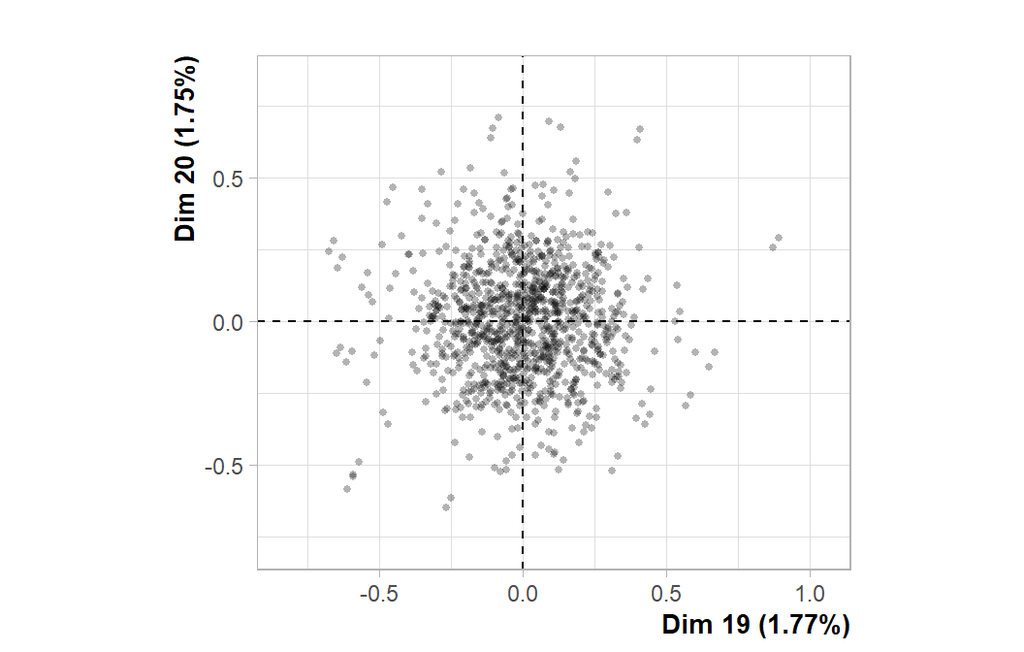

**Figure 12.1 - Graphe des individus (ACM)** *Les individus libellés sont ceux ayant la plus grande contribution à la construction du plan.*

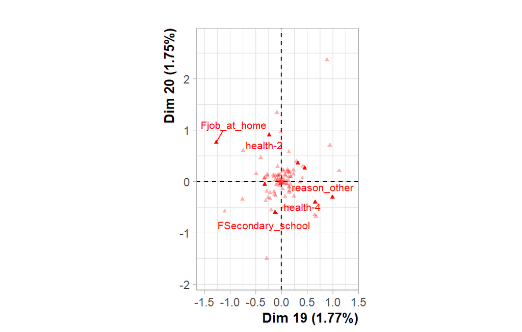

**Figure 12.2 - Graphe des variables (ACM)** *Les variables libellées sont celles les mieux représentées sur le plan.*

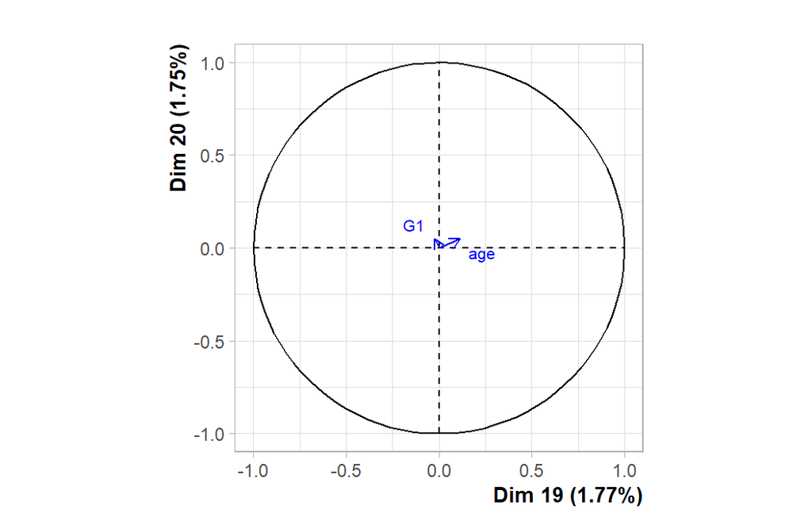

**Figure 12.3 - Graphe des variables quantitatives (ACM)** *Les variables libellées sont celles les mieux représentées sur le plan.*

La **dimension 19** oppose des individus caractérisés par une coordonnée fortement positive sur l’axe (à droite du graphe) à des individus caractérisés par une coordonnée fortement négative sur l’axe (à gauche du graphe).

Le groupe 1 (caractérisés par une coordonnée positive sur l’axe) partage :

- une forte fréquence des modalités telles que *famrel=famrel-5*, *health=health-4*, *Walc=Walc-1*, *guardian=guardian_mother*, *reason=reason_other*, *nursery=nurs-YES*, *Dalc=Dalc-1*, *studytime=s5-10*, *goout=go_out-3* et *famsize=GT3* (du plus commun au plus rare).
- une faible fréquence des modalités telles que *famrel=famrel-4*, *guardian=guardian_father*, *Fjob=Fjob_at_home*, *nursery=nurs-NO*, *reason=reason_course*, *freetime=freet-5*, *goout=go_out-2*, *Dalc=Dalc-2*, *failures=1* et *famsize=LE3* (du plus rare au plus commun).

Le groupe 2 (caractérisés par une coordonnées négative sur l’axe) partage :

- une forte fréquence des modalités telles que *famrel=famrel-4*, *health=health-5*, *freetime=freet-5*, *Fjob=Fjob_at_home*, *guardian=guardian_father*, *nursery=nurs-NO*, *goout=go_out-2*, *reason=reason_course*, *Medu=MPrimary_school* et *Fedu=FPrimary_school* (du plus commun au plus rare).
- une faible fréquence des modalités telles que *famrel=famrel-5*, *health=health-4*, *nursery=nurs-YES*, *freetime=freet-4*, *studytime=s5-10*, *reason=reason_other*, *guardian=guardian_mother*, *activities=act-YES*, *goout=go_out-3* et *famsize=GT3* (du plus rare au plus commun).

Le groupe 3 (caractérisés par une coordonnées négative sur l’axe) partage :

- une forte fréquence des modalités telles que *health=health-2*, *Dalc=Dalc-3*, *freetime=freet-4*, *famrel=famrel-1*, *failures=1*, *guardian=guardian_other*, *Medu=MNone*, *Mjob=Mjob_at_home*, *Fjob=Fjob_at_home* et *Fedu=FHigh_education* (du plus commun au plus rare).
- une faible fréquence des modalités telles que *Fedu=FSecondary_school*, *Medu=MSecondary_school*, *health=health-4*, *guardian=guardian_mother*, *Fjob=Fjob_other*, *failures=0*, *Walc=Walc-4*, *traveltime=t15-30*, *famsize=GT3* et *goout=go_out-2* (du plus rare au plus commun).

La **dimension 20** oppose des individus caractérisés par une coordonnée fortement positive sur l’axe (en haut du graphe) à des individus caractérisés par une coordonnée fortement négative sur l’axe (en bas du graphe).

Le groupe 1 (caractérisés par une coordonnée positive sur l’axe) partage :

- une forte fréquence des modalités telles que *health=health-2*, *Dalc=Dalc-3*, *freetime=freet-4*, *famrel=famrel-1*, *failures=1*, *guardian=guardian_other*, *Medu=MNone*, *Mjob=Mjob_at_home*, *Fjob=Fjob_at_home* et *Fedu=FHigh_education* (du plus commun au plus rare).
- une faible fréquence des modalités telles que *Fedu=FSecondary_school*, *Medu=MSecondary_school*, *health=health-4*, *guardian=guardian_mother*, *Fjob=Fjob_other*, *failures=0*, *Walc=Walc-4*, *traveltime=t15-30*, *famsize=GT3* et *goout=go_out-2* (du plus rare au plus commun).

Le groupe 2 (caractérisés par une coordonnée positive sur l’axe) partage :

- une forte fréquence des modalités telles que *famrel=famrel-5*, *health=health-4*, *Walc=Walc-1*, *guardian=guardian_mother*, *reason=reason_other*, *nursery=nurs-YES*, *Dalc=Dalc-1*, *studytime=s5-10*, *goout=go_out-3* et *famsize=GT3* (du plus commun au plus rare).
- une faible fréquence des modalités telles que *famrel=famrel-4*, *guardian=guardian_father*, *Fjob=Fjob_at_home*, *nursery=nurs-NO*, *reason=reason_course*, *freetime=freet-5*, *goout=go_out-2*, *Dalc=Dalc-2*, *failures=1* et *famsize=LE3* (du plus rare au plus commun).

Le groupe 3 (caractérisés par une coordonnées négative sur l’axe) partage :

- une forte fréquence des modalités telles que *Fedu=FSecondary_school*, *health=health-3*, *Walc=Walc-4*, *Dalc=Dalc-2*, *activities=act-YES*, *famrel=famrel-3*, *Fjob=Fjob_other*, *romantic=rom-NO*, *freetime=freet-2* et *Medu=MSecondary_school* (du plus commun au plus rare).
- une faible fréquence des modalités telles que *health=health-2*, *Fedu=F5th_9th_grade*, *famrel=famrel-5*, *freetime=freet-4*, *activities=act-NO*, *Fjob=Fjob_at_home*, *Dalc=Dalc-3*, *romantic=rom-YES*, *Walc=Walc-1* et *goout=go_out-3* (du plus rare au plus commun).

### 13. Description du plan 21:22

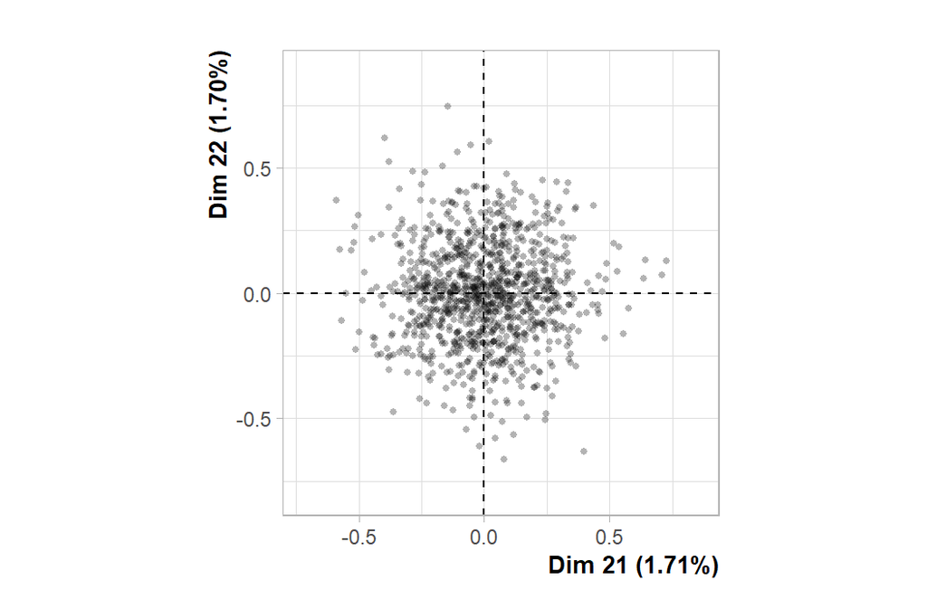

**Figure 13.1 - Graphe des individus (ACM)** *Les individus libellés sont ceux ayant la plus grande contribution à la construction du plan.*

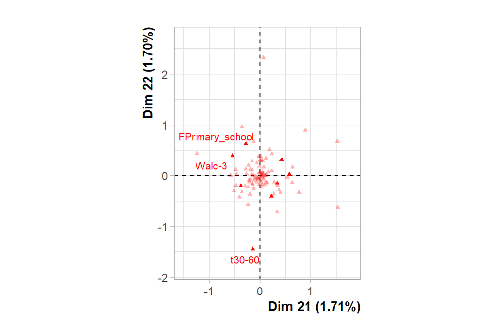

**Figure 13.2 - Graphe des variables (ACM)** *Les variables libellées sont celles les mieux représentées sur le plan.*

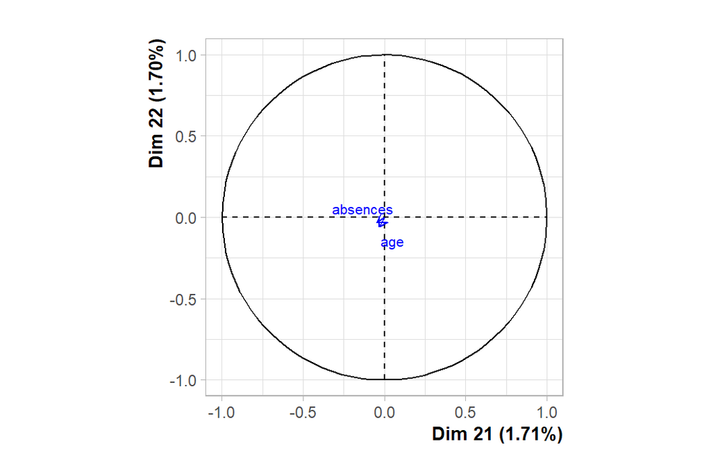

**Figure 13.3 - Graphe des variables quantitatives (ACM)** *Les variables libellées sont celles les mieux représentées sur le plan.*

La **dimension 21** oppose des individus caractérisés par une coordonnée fortement positive sur l’axe (à droite du graphe) à des individus caractérisés par une coordonnée fortement négative sur l’axe (à gauche du graphe).

Le groupe 1 (caractérisés par une coordonnée positive sur l’axe) partage :

- une forte fréquence des modalités telles que *reason=reason_course*, *Fedu=F5th_9th_grade*, *traveltime=t30-60*, *studytime=s2-5*, *Walc=Walc-4*, *goout=go_out-4*, *Fjob=Fjob_at_home*, *famrel=famrel-3*, *nursery=nurs-YES* et *Dalc=Dalc-4* (du plus commun au plus rare).
- une faible fréquence des modalités telles que *Fedu=FPrimary_school*, *Walc=Walc-3*, *nursery=nurs-NO*, *reason=reason_reputation*, *health=health-5*, *reason=reason_other*, *famrel=famrel-4*, *studytime=s0-2*, *failures=3* et *Mjob=Mjob_services* (du plus rare au plus commun).

Le groupe 2 (caractérisés par une coordonnées négative sur l’axe) partage :

- une forte fréquence des modalités telles que *goout=go_out-3*, *reason=reason_home*, *activities=act-YES*, *Pstatus=A*, *Mjob=Mjob_health*, *nursery=nurs-NO*, *health=health-2*, *Fjob=Fjob_other*, *Mjob=Mjob_other* et *Walc=Walc-2* (du plus commun au plus rare).
- une faible fréquence des modalités telles que *Fjob=Fjob_services*, *reason=reason_course*, *activities=act-NO*, *Pstatus=T*, *nursery=nurs-YES*, *Mjob=Mjob_services*, *goout=go_out-4*, *health=health-1*, *Mjob=Mjob_at_home* et *Walc=Walc-4* (du plus rare au plus commun).

La **dimension 22** oppose des individus caractérisés par une coordonnée fortement positive sur l’axe (en haut du graphe) à des individus caractérisés par une coordonnée fortement négative sur l’axe (en bas du graphe).

Le groupe 1 (caractérisés par une coordonnée positive sur l’axe) partage :

- une forte fréquence des modalités telles que *Fedu=FPrimary_school*, *Mjob=Mjob_services*, *reason=reason_other*, *famsup=famsup-YES*, *Medu=MPrimary_school*, *health=health-5*, *Dalc=Dalc-2*, *Fjob=Fjob_services*, *goout=go_out-2* et *Walc=Walc-3* (du plus commun au plus rare).
- une faible fréquence des modalités telles que *traveltime=t30-60*, *Fedu=F5th_9th_grade*, *famsup=famsup-NO*, *reason=reason_home*, *health=health-4*, *Fjob=Fjob_at_home*, *Walc=Walc-2*, *romantic=rom-YES*, *famrel=famrel-3* et *Mjob=Mjob_teacher* (du plus rare au plus commun).

Le groupe 2 (caractérisés par une coordonnées négative sur l’axe) partage :

- une forte fréquence des modalités telles que *goout=go_out-3*, *reason=reason_home*, *activities=act-YES*, *Pstatus=A*, *Mjob=Mjob_health*, *nursery=nurs-NO*, *health=health-2*, *Fjob=Fjob_other*, *Mjob=Mjob_other* et *Walc=Walc-2* (du plus commun au plus rare).
- une faible fréquence des modalités telles que *Fjob=Fjob_services*, *reason=reason_course*, *activities=act-NO*, *Pstatus=T*, *nursery=nurs-YES*, *Mjob=Mjob_services*, *goout=go_out-4*, *health=health-1*, *Mjob=Mjob_at_home* et *Walc=Walc-4* (du plus rare au plus commun).

Le groupe 3 (caractérisés par une coordonnées négative sur l’axe) partage :

- une forte fréquence des modalités telles que *reason=reason_course*, *Fedu=F5th_9th_grade*, *traveltime=t30-60*, *studytime=s2-5*, *Walc=Walc-4*, *goout=go_out-4*, *Fjob=Fjob_at_home*, *famrel=famrel-3*, *nursery=nurs-YES* et *Dalc=Dalc-4* (du plus commun au plus rare).
- une faible fréquence des modalités telles que *Fedu=FPrimary_school*, *Walc=Walc-3*, *nursery=nurs-NO*, *reason=reason_reputation*, *health=health-5*, *reason=reason_other*, *famrel=famrel-4*, *studytime=s0-2*, *failures=3* et *Mjob=Mjob_services* (du plus rare au plus commun).